# Building buy/sell strategies based on top investors behaviour

## 1. Intoduction: The 13F filings

The SEC's 13F is a quarterly report required to be filed by institutional managers that manage at least 100$ million. It discloses their equity holdings and can provide insights into what the top managers are doing. It informs what was bought and sold in the past quarter and must be filed until the filings date, 45 days after the end of the quarter.

[figure not shown]

As there is a 45 delay between the end of the semester and the filings date, as well as a delay from when the transaction was made, the stock purchases may have been made 45 to 135 days prior to the reported date, making the information less reliable and making it impossible to benefit from any transaction made because of short-term events.

The objective of this analysis will be to explore if, by considering the actions of multiple funds (and trying to find which stocks they seem to agree on), it is possible to find stocks that are likely to perform better than the S&P in the period after the filings date.

## 2. Collecting the data:

A webscraper was built to extract both the information of the past transactions made by the managers, as well as the stock prices in key dates.

#### Top managers

The data regarding the top managers characteristics can be found in https://www.dataroma.com/m/managers.php. It informs:

- Name of the fund
- Amount of capital held by the fund
- Number of stocks the fund has at the current moment
- Top 10 holdings at the moment

[figure not shown]

#### Historical transactions by fund

In the same website, the historical transactions each fund made by quarter is also reported (Ex:https://www.dataroma.com/m/m_activity.php?m=AIM&typ=a):

- Quarter of transaction
- Stocks the fund moved in the quarter.
- If the fund ended up with a net buy or net sell at the end of the semester.
- How much change this sell/buy action corresponded to the overall portfolio in %.

[figure not shown]

#### Stock prices

For each stock in each quarter, the prices in key dates (start semester, end semester, start of filings date this semester, start of filings date next semester) were obtained using yahoo finance.

- start_date: Date the semester started
- end_date: Date the semester ended
- start_filings: Filings date of the semester (45 days after end_date)
- end_filings: Filings date of the next semester (45 days after next semester's end date)

Each date has a corresponding stock price and SPY (S&P500) price.

For each transaction, a variable "alpha_1sem+45" is obtained: It is the return between the start_filings and end_filings date the stock had above the SPY.

As an example, suppose AAPL was one of the stocks most bought in 2021Q1:

Start date: 01/01/2021

End date:31/03/2021

Start filings: 16/05/2021 (Price: 127.45$ - Price SPY: 415.52$)

End filings: 16/08/2021 (Price: 151.12$ - Price SPY: 446.97$)

Inc_1sem+45 (AAPL)=(151.12-127.45)/127.45=18.6%

Inc_1sem+45_spy =(446.97-415.2)/415.52=7.6%

Alpha_1sem+45=18.6%-7.65% = 11%

By looking into what the investors did in the first 3 months of the year and investing in the stock from may to august, it was possible to obtain a gain 11% higher than the gain of the S&P in the same period.

The table below shows a sample of 20 buy/sell actions with the information mentioned above.

```python
from IPython.display import Markdown as md

import numpy as np
import itertools
import pandas as pd
pd.set_option('display.max_columns', None)
pd.set_option('display.max_rows', 20)
import statsmodels.api as sm
from statsmodels.stats.outliers_influence import summary_table
from scipy.stats import ttest_rel,pearsonr,ttest_ind
import datetime
import matplotlib.pyplot as plt
from  matplotlib.colors import LinearSegmentedColormap
import matplotlib.gridspec as gridspec
import matplotlib.lines as mlines
import seaborn as sns
import warnings
warnings.filterwarnings('ignore')
cmap=LinearSegmentedColormap.from_list('rg',["r", "w", "g"], N=256)

filter_percent_port=1
max_number_of_stocks_in_port=100
perc_increase_cap=5
number_of_selections=3

def newline(p1, p2,ax,color):
    l = mlines.Line2D([p1[0],p2[0]], [p1[1],p2[1]], color=color,zorder=1,linewidth=2)
    ax.add_line(l)
    return l
```

```python
def read_data_excel():
    data= pd.read_excel('summary_buy_sells_v2.xlsx', index_col=0)
    data['year']=data['Quarter'].apply(lambda x:int(x.split(' ')[0]))
    for col in ['start_price','end_price','start_filings_price','end_filings_price']:
        data=data[data[col]>0.01]
    data=data.dropna(subset=['start_price','end_price','start_filings_price','end_filings_price'],axis=0)
    data['Inc_1sem']=(data['end_price']-data['start_price'])/data['start_price']
    data['Inc_1sem+45']=(data['end_filings_price']-data['start_filings_price'])/data['start_filings_price']
    data['Inc_1y+45']=(data['end_filings_1y_price']-data['start_filings_price'])/data['start_filings_price']

    data['Inc_1sem_spy']=(data['end_price_spy']-data['start_price_spy'])/data['start_price_spy']
    data['Inc_1sem+45_spy']=(data['end_filings_price_spy']-data['start_filings_price_spy'])/data['start_filings_price_spy']
    data['Inc_1y+45_spy']=(data['end_filings_1y_price_spy']-data['start_filings_price_spy'])/data['start_filings_price_spy']

    data['alpha_1sem']=data['Inc_1sem']-data['Inc_1sem_spy']
    data['alpha_1sem+45']=data['Inc_1sem+45']-data['Inc_1sem+45_spy']
    data['alpha_1y']=data['Inc_1y+45']-data['Inc_1y+45_spy']
    return data

data= read_data_excel()
data.sample(20)[['Quarter','Investor','portfolio_size','stocks_in_port','Action','Ticker','Company','% change to portfolio','start_date','end_date',
                'start_filings','end_filings','start_filings_price','end_filings_price','start_filings_price_spy',
                 'end_filings_price_spy','Inc_1sem+45','Inc_1sem+45_spy','alpha_1sem+45']]
```

|  | Quarter | Investor | portfolio_size | stocks_in_port | Action | Ticker | Company | % change to portfolio | start_date | end_date | start_filings | end_filings | start_filings_price | end_filings_price | start_filings_price_spy | end_filings_price_spy | Inc_1sem+45 | Inc_1sem+45_spy | alpha_1sem+45 |
| --- | --- | --- | --- | --- | --- | --- | --- | --- | --- | --- | --- | --- | --- | --- | --- | --- | --- | --- | --- |
| 8342 | 2012 Q1 | Hillman Value Fund | 196 | 33 | Sell | JPM | JPMorgan Chase & Co. | 0.66 | 2012-01-01 | 2012-03-31 | 2012-05-15 | 2012-08-14 | 27.854241 | 29.041071 | 111.535865 | 118.195502 | 0.042609 | 0.059708 | -0.017100 |
| 274 | 2015 Q4 | Alex Roepers | 318 | 9 | Sell | WCC | WESCO International Inc. | 9.23 | 2015-10-01 | 2015-12-31 | 2016-02-15 | 2016-05-16 | 40.650002 | 54.230000 | 166.305349 | 185.238673 | 0.334071 | 0.113847 | 0.220225 |
| 30 | 2020 Q3 | AKO Capital | 8880 | 26 | Sell | LIN | Linde plc | 1.61 | 2020-07-01 | 2020-09-30 | 2020-11-16 | 2021-02-15 | 254.555256 | 249.226256 | 355.965690 | 386.073354 | -0.020935 | 0.084580 | -0.105515 |
| 19392 | 2008 Q1 | Bruce Berkowitz | 1270 | 15 | Buy | MHK | Mohawk Industries | 1.28 | 2008-01-01 | 2008-03-31 | 2008-05-15 | 2008-08-14 | 77.320000 | 66.190002 | 107.672349 | 98.083397 | -0.143947 | -0.089057 | -0.054890 |
| 7861 | 2015 Q2 | Harry Burn | 1250 | 39 | Sell | MSFT | Microsoft Corp. | 2.81 | 2015-04-01 | 2015-06-30 | 2015-08-14 | 2015-11-16 | 41.706944 | 47.891750 | 185.335889 | 180.838207 | 0.148292 | -0.024268 | 0.172560 |
| 17720 | 2008 Q3 | Wallace Weitz | 953 | 27 | Sell | BBBY | Bed Bath & Beyond | 0.44 | 2008-07-01 | 2008-09-30 | 2008-11-14 | 2009-02-16 | 18.908878 | 19.342566 | 68.995607 | 64.996936 | 0.022936 | -0.057955 | 0.080891 |
| 25842 | 2020 Q4 | Hillman Value Fund | 196 | 33 | Buy | MRK | Merck & Co. | 1.25 | 2020-10-01 | 2020-12-31 | 2021-02-15 | 2021-05-17 | 70.074393 | 74.427048 | 386.073354 | 412.713270 | 0.062115 | 0.069002 | -0.006887 |
| 26173 | 2007 Q3 | Hillman Value Fund | 196 | 33 | Buy | DHI | D.R. Horton | 2.31 | 2007-07-01 | 2007-09-30 | 2007-11-14 | 2008-02-14 | 10.384042 | 12.217082 | 112.757442 | 104.034919 | 0.176525 | -0.077357 | 0.253881 |
| 16650 | 2018 Q4 | Tweedy Browne Co. | 424 | 63 | Sell | CMCSA | Comcast Corp. | 1.18 | 2018-10-01 | 2018-12-31 | 2019-02-14 | 2019-05-15 | 35.142745 | 40.860940 | 261.211109 | 269.845923 | 0.162713 | 0.033057 | 0.129657 |
| 1596 | 2020 Q2 | Charles Bobrinskoy | 66 | 28 | Sell | MOS | Mosaic Co. | 0.26 | 2020-04-01 | 2020-06-30 | 2020-08-14 | 2020-11-16 | 17.171582 | 18.328432 | 330.414341 | 355.965690 | 0.067370 | 0.077331 | -0.009961 |
| 17431 | 2016 Q2 | Wallace Weitz | 953 | 27 | Sell | RRC | Range Resources Corp. | 2.53 | 2016-04-01 | 2016-06-30 | 2016-08-15 | 2016-11-14 | 37.865723 | 31.283612 | 198.857125 | 198.163288 | -0.173828 | -0.003489 | -0.170339 |
| 32623 | 2010 Q3 | Steven Romick | 7770 | 55 | Buy | RIG | Transocean Ltd. | 1.69 | 2010-07-01 | 2010-09-30 | 2010-11-15 | 2011-02-14 | 54.390440 | 61.467561 | 97.347781 | 107.963880 | 0.130117 | 0.109053 | 0.021064 |
| 30923 | 2021 Q1 | Ruane, Cunniff & Goldfarb | 4780 | 29 | Buy | MU | Micron Technology Inc. | 3.56 | 2021-01-01 | 2021-03-31 | 2021-05-17 | 2021-08-16 | 79.099998 | 70.199997 | 412.713270 | 443.110423 | -0.112516 | 0.073652 | -0.186168 |
| 10996 | 2020 Q1 | Mason Hawkins | 1490 | 15 | Sell | MAT | Mattel Inc. | 1.32 | 2020-01-01 | 2020-03-31 | 2020-05-15 | 2020-08-14 | 8.060000 | 11.610000 | 276.122340 | 330.414341 | 0.440447 | 0.196623 | 0.243824 |
| 7099 | 2020 Q1 | Glenn Greenberg | 2910 | 24 | Sell | LEN | Lennar Corp. | 1.52 | 2020-01-01 | 2020-03-31 | 2020-05-15 | 2020-08-14 | 47.567981 | 73.298490 | 276.122340 | 330.414341 | 0.540921 | 0.196623 | 0.344298 |
| 24975 | 2012 Q2 | Glenn Greenberg | 2910 | 24 | Buy | CMPR | Cimpress plc | 1.29 | 2012-04-01 | 2012-06-30 | 2012-08-14 | 2012-11-14 | 39.000000 | 29.980000 | 118.195502 | 116.236105 | -0.231282 | -0.016578 | -0.214704 |
| 7153 | 2017 Q3 | Glenn Greenberg | 2910 | 24 | Sell | IQV | IQVIA Holdings Inc. | 2.90 | 2017-07-01 | 2017-09-30 | 2017-11-14 | 2018-02-14 | 102.580002 | 100.980003 | 239.788920 | 247.475097 | -0.015598 | 0.032054 | -0.047651 |
| 6709 | 2017 Q2 | FPA Queens Road Small Cap Value Fund | 412 | 54 | Sell | AVT | Avnet Inc. | 2.70 | 2017-04-01 | 2017-06-30 | 2017-08-14 | 2017-11-14 | 34.280097 | 35.962315 | 227.648306 | 239.788920 | 0.049073 | 0.053331 | -0.004258 |
| 19626 | 2018 Q1 | Charles Bobrinskoy | 66 | 28 | Buy | SJM | J.M. Smucker Co | 0.51 | 2018-01-01 | 2018-03-31 | 2018-05-15 | 2018-08-14 | 100.432201 | 100.595191 | 255.309892 | 267.154979 | 0.001623 | 0.046395 | -0.044772 |
| 17143 | 2020 Q2 | Viking Global Investors | 32900 | 87 | Sell | MOH | Molina Healthcare Inc. | 0.27 | 2020-04-01 | 2020-06-30 | 2020-08-14 | 2020-11-16 | 192.559998 | 221.830002 | 330.414341 | 355.965690 | 0.152005 | 0.077331 | 0.074673 |

```python
median_alpha_of_buy_transactions=data[data['Action']=='Buy'][['alpha_1sem+45']].dropna().median()[0]

perc_of_buy_transactions_with_positive_alpha=(data[data['Action']=='Buy']['alpha_1sem+45']>0).mean()

median_alpha_of_sell_transactions=data[data['Action']=='Sell'][['alpha_1sem+45']].dropna().median()[0]

perc_of_sell_transactions_with_positive_alpha=(data[data['Action']=='Sell']['alpha_1sem+45']>0).mean()

md('When looking at all the buy transactions (increase of stock in portfolio), the transactions had a median alpha (return above SPY) of **{:.2f}%**. Out of all the buy transactions, **{:.2f}%** had a positive alpha.\n When considering the sell transactions (decrease of stock in portfolio), the transactions had a median alpha (return above SPY) of **{:.2f}%**. Out of all the sell transactions, **{:.2f}%** had a positive alpha.\n'.format(median_alpha_of_buy_transactions*100,perc_of_buy_transactions_with_positive_alpha*100,median_alpha_of_sell_transactions*100,perc_of_sell_transactions_with_positive_alpha*100))
```

When looking at all the buy transactions (increase of stock in portfolio), the transactions had a median alpha (return above SPY) of **0.16%**. Out of all the buy transactions, **50.48%** had a positive alpha. When considering the sell transactions (decrease of stock in portfolio), the transactions had a median alpha (return above SPY) of **-0.27%**. Out of all the sell transactions, **49.16%** had a positive alpha.

# 3. Defining the objective, hypothesis and methodology

Before processing and filtering the data, it is important to have a well defined objective, set of hypothesis and idea of how the algorithm will work.

## 3.1 Objective

The objective of the analysis will be to build a set of rules based on investor and transaction information that can indicate which funds are likely perform above the S&P and which funds are likely to perform below the S&P.

The strategies will be based on the group of investors, rather than any particular fund. They will be based on the net number of funds that bought the stock (number that bought - number that sold), as well as how much change there was (Transactions with higher % change to portfolio are likely to be more important).

## 3.2 Hypothesis and simplifications

Simplifications

- Dividends will not be considered.

Hypothesis

- There is a high enough number of funds to base the analysis on (the data extracted from the site included only 72 funds, but there are many more that fill 13F's and did not appear).
- It is also assumed there was no biased criteria the site used to choose the 72 investors presented in the webpage.
- Transactions with a higher "% change to portfolio" are likely to be more important.
- Managers that hold a lower number of stocks are likely to be more precise in their choice. A transaction made in a fund with 600 stocks is likely to be less important than a transaction made by a fund that has 10 stocks, for example.
- Funds behaved in a similar way both in past and present (number of stocks in portfolio did not change a lot over the years)

## 3.3 Methodology

1. Filters are applied to disconsider transactions judged unimportant (Ex: transactions that had a change in portfolio of less than 0.2%). The filters and subset of data considered are analyzed in the next section.
2. Strategies are built around the following criteria:
- Strategy 1: Buying funds with highest net buy/sells (Ex: buying a fund because it had a value of 6 net buy/sell: - 8 buys ans 2 sells)
- Strategy 2: Buying funds with highest net % change to portfolio (Ex: buying a fund because it had a value of 8.5% net change: 1 fund increased 4%, other fund increased 5%, other fund decreased 0.5%)
- Strategy 3: Buying funds with highest net buy/sell, taking into consideration past fund performances. Same as strategy 1, but best performing funds have a higher weight to their actions.
1. Sensibility analysis: Study how modifications in the filters may modify the performance of the strategies.

# 4. Studying, processing and filtering the data

## 4.1 Choosing filters

### 4.1.1 Choosing the limit of stocks in a fund

The idea of this filter is to exclude funds that have too many held stocks, as they may be less imporant and decisive than funds that have very few held stocks.

On the other hand, it is not interesting to limit the maxmimum number of stocks held too low, as there won't be enough funds and data to base the strategies on.

The figure below shows that very few funds have more than 100 held stocks. It also shows that considering only funds with less than 20 stocks reduces the data size too much: Almost no transaction (unique stock+quarter combination) appeared more than 3 times.

For now, only funds with less than 100 stocks will be considered.

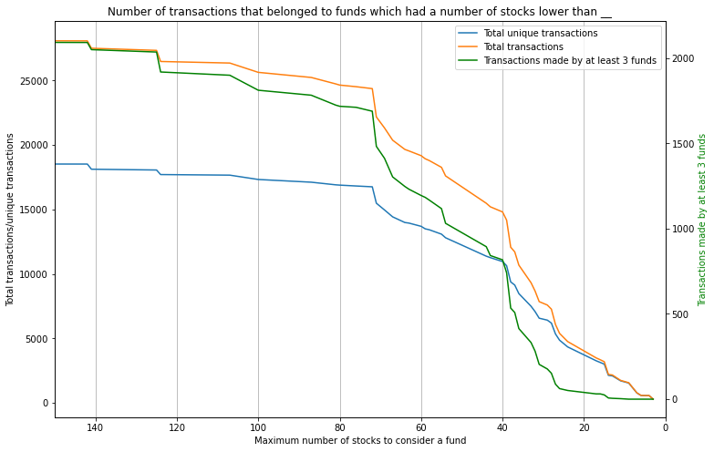

```python
def plot_numb_transactions_as_function_of_variable(x_var,xlabel,title,x_limit):
    row_list=[]

    for stocks_in_port in sorted(list(pd.unique(data[x_var]))):
        if x_var=='stocks_in_port':
            var_df=data[data[x_var]<=stocks_in_port]
        else:
            var_df=data[data[x_var]>=stocks_in_port]
        unique_values=var_df.drop_duplicates(subset=['Quarter','Ticker'])
        higher_than_3_transactions=var_df.groupby(['Quarter','Ticker']).count()[['Action']].reset_index()
        higher_than_3_transactions=higher_than_3_transactions[higher_than_3_transactions['Action']>=3].count()['Action']
        row_list+=[[unique_values.shape[0],var_df.shape[0],stocks_in_port,higher_than_3_transactions]]

    df_change=pd.DataFrame(row_list,columns=['unique_values','total_values','x_var','more_than_3_transactions'])
    fig,ax1=plt.subplots(figsize=(12,8))
    ax2 = ax1.twinx()

    l1=ax1.plot(df_change['x_var'],df_change['unique_values'],label='Total unique transactions')
    l2=ax1.plot(df_change['x_var'],df_change['total_values'],label='Total transactions')
    l3=ax2.plot(df_change['x_var'],df_change['more_than_3_transactions'],label='Transactions made by at least 3 funds',
                c='green')
    lns=l1+l2+l3
    ax1.legend(lns,[l.get_label() for l in lns],loc=0)
    plt.xlim(x_limit)

    ax2.set_ylabel('Transactions made by at least 3 funds',color='green')
    ax1.set_ylabel('Total transactions/unique transactions',color='black')
    ax1.set_xlabel(xlabel)
    ax1.set_title(title)
    #ax1.set_xticks([0.2,0.5,1,2,3,4,5])
    ax1.grid(axis='x')
    if x_var=='stocks_in_port':
        ax1.invert_xaxis()
    if x_var=='% change to portfolio':
        ax1.set_xticks([0.2,0.5,1,2,3,4,5])
        ax1.set_ylim(0,30000)
        ax2.set_ylim(0,3000)

plot_numb_transactions_as_function_of_variable('stocks_in_port','Maximum number of stocks to consider a fund',
    'Number of transactions that belonged to funds which had a number of stocks lower than __',(0,150))
```

### 4.1.2 Choosing the minimum % change required

Some of the funds operations presented a very low "% change to portfolio", sometimes as low as 0.01%. These low transactions don't indicate a change in strategy of the fund regarding the stock (it could just be a small movimentation of the funds portfolio), and are only adding noise.

It is interesting to filter transactions with changes to portfolio too small. At the same time, if this filter value is too high, the filter may be too strong and not enough data is left to analyze.

The graph below shows that only limiting transactions to changes of at least 3% leaves us with less than 150 transactions (unique combinations of stock+quarter) made by at least 3 investors. For this initial analysis, the chosen limit will be 1%.

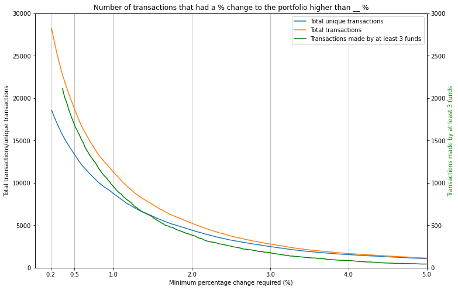

```python
plot_numb_transactions_as_function_of_variable('% change to portfolio',
'Minimum percentage change required (%)','Number of transactions that had a % change to the portfolio higher than __ %',(0,3))
```

### 4.1.3 Capping the % change to portfolio.

The second strategy will use the sum of the "net % change", trusting that funds that made a higher investment (Ex: 5% of portfolio into BABA) are much more confident in the stock than funds that made a lower investment (Ex: 0.35% of portfolio into BABA).

The problem arises however when a fund makes a bet that represents a very large amount of their portfolio, thus making it the sole decider on the investment (Ex: in one quarter, suppose a fund increased the position in BABA to 30% of portfolio, while 10 other funds increased the position into AAPL by 2.5%. The method would choose BABA, solely because it has the highest sum value).

To avoid this problem on basing the strategy on one big bet, the % change to portfolio is capped at a certain value. For this current analysis the value used will be 5%. However the sensibility regarding this value will be studied on a later section.

### 4.1.4 Choosing the period of analysis

As shown in the graph below, most of the funds operations appeared in more recent years.

```python
def data_filter_and_process(data_in,filter_percent_port,max_number_of_stocks_in_port,perc_increase_cap):
    data_out=data_in[(data_in['% change to portfolio']>filter_percent_port)&(data_in['stocks_in_port']<max_number_of_stocks_in_port)]

    data_out['% change to portfolio']=data_out['% change to portfolio'].apply(lambda x:min(x,perc_increase_cap))
    return data_out
data_filt=data_filter_and_process(data,filter_percent_port,max_number_of_stocks_in_port,perc_increase_cap)
```

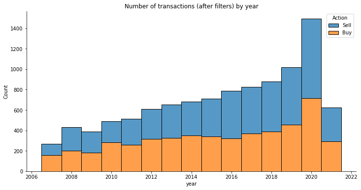

```python
plt.figure(figsize=(12,6))
sns.histplot(data_filt,x='year',hue='Action',multiple='stack',discrete=True)
plt.title("Number of transactions (after filters) by year".format(filter_percent_port))
sns.despine()
```

Analyzing the number of unique funds that appeared in each year the phenomenom above is explained: Very few funds appeared in the initial years the webpage has data on. In order to have an sufficient number of funds to base the analyses on, the analysis will consider only the operations made after 2013.

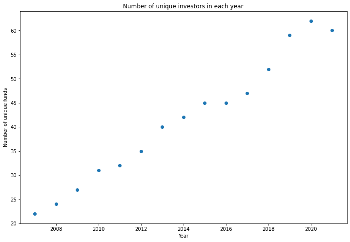

```python
dict_investors_by_year={}
for year in sorted(list(pd.unique(data_filt['year']))):
    data_year=data_filt[data_filt['year']==year]
    number_of_unique_funds=len(pd.unique(data_year['Investor']))
    dict_investors_by_year[year]=number_of_unique_funds

plt.figure(figsize=(12,8))
plt.scatter(dict_investors_by_year.keys(),dict_investors_by_year.values())
plt.xlabel('Year')
plt.ylabel('Number of unique funds')
plt.title('Number of unique investors in each year')

data_filt=data_filt[data_filt['year']>=2013]
```

### 4.1.4 Results of the filters

```python
md('Out of the **{}** original trades, only **{}** had price data on the period (using yahoo finance), as well as fit the filter conditions'.format(data.shape[0],data_filt.shape[0]))
```

Out of the **28224** original trades, only **7670** had price data on the period (using yahoo finance), as well as fit the filter conditions

## 4.2 Investor analysis

In this section, it will be analyzed if funds that performed well in the past are likely to perform well in the future.

The characteristics of the funds will also be studied to see if there is anything that can indicate a better performance.

### 4.2.1 Correlation of past performance and future performance.

To test wheter funds that overperformed in the past are likely to overperform in the future we will consider the alpha of each transaction.

```python
#######################################
####INVESTOR ANALYSIS##################
#######################################

investors=pd.unique(data['Investor'])

list_investors_insufficient_data_bef_2018=[]
investors_score=[]
for investor in investors:
    data_investor_bef_2018=data_filt[(data_filt['Quarter'].apply(lambda x:int(x.split(' ')[0]))<2018)&(data_filt['Investor']==investor)]
    if data_investor_bef_2018.shape[0]<20:
        list_investors_insufficient_data_bef_2018+=[investor]
    else:
        investors_score+=[[investor,data_investor_bef_2018['alpha_1sem+45'].median(),data_investor_bef_2018['alpha_1sem+45'].mean(),(data_investor_bef_2018['alpha_1sem+45']>0).mean()]]

#score investors based on past performance
investor_order=list(pd.DataFrame(investors_score).sort_values(by=2,ascending=False)[0])
subset_len=len(investor_order)/4
score=4
i=0
investor_score={}
for investor in investor_order:
    if i>subset_len-1:
        i=0
        score-=1
    investor_score[investor]=score
    i+=1
for investor in investors:
    if not investor in investor_score:
        investor_score[investor]=2.5
```

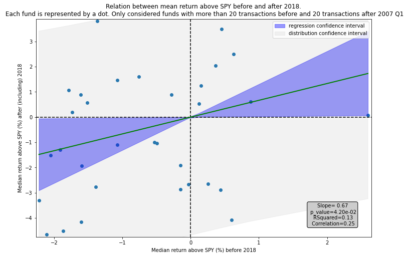

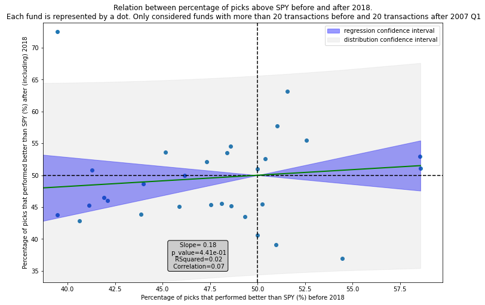

```python
#####STUDYING IF PAST GOOD INVESTMENTS ARE CORRELATED WITH PRESENT GOOD INVESTMENTS
investors_score_aft_2018=[]

for investor in investors:
    data_investor_aft_2018=data_filt[(data_filt['Quarter'].apply(lambda x:int(x.split(' ')[0]))>=2018)&(data_filt['Investor']==investor)]
    if data_investor_aft_2018.shape[0]<30:
        continue
    else:
        investors_score_aft_2018+=[[investor,data_investor_aft_2018['alpha_1sem+45'].median(),data_investor_aft_2018['alpha_1sem+45'].mean(),(data_investor_aft_2018['alpha_1sem+45']>0).mean()]]

df_bef_2018=pd.DataFrame(investors_score,columns=['Investor','median_bef_2018','mean_bef_2018','positive%_bef_2018'])
df_aft_2018=pd.DataFrame(investors_score_aft_2018,columns=['Investor','median_aft_2018','mean_aft_2018','positive%_aft_2018'])
merged_df_funds_comparison=df_bef_2018.merge(df_aft_2018,on='Investor',how='inner')

def plot_confidence_interval(df,x_var,y_var,xlabel,ylabel,title,correction):
    df=df.sort_values(by=x_var)
    x=df[[x_var]]-correction
    y=df[y_var]-correction
    model=sm.OLS (y,x).fit()
    st, data, ss2 = summary_table(model, alpha=0.05)

    fittedvalues = data[:, 2]
    predict_mean_ci_low, predict_mean_ci_upp = data[:, 4:6].T
    predict_ci_low, predict_ci_upp = data[:, 6:8].T
    slope=model.params[0]
    p_value=pd.read_html(model.summary().tables[1].as_html(),header=0,index_col=0)[0]['P>|t|'][0]
    r2=pd.read_html(model.summary().tables[0].as_html(),index_col=0)[0][3][0]
    corr=pearsonr(df[x_var],df[y_var])[0]
    plt.figure(figsize=(12,8))
    plt.scatter(df[x_var]*100,df[y_var]*100)
    #plt.plot([-7.5,7.5],[-7.5,7.5],'k--')
    plt.plot([0+correction*100,0+correction*100],[(min(y)+correction)*100*1.02,(max(y)+correction)*100*1.02],'k--')
    plt.plot([(min(x.values)[0]+correction)*100*1.02,(max(x.values)[0]+correction)*100*1.02],[0+correction*100,0+correction*100],'k--')
    plt.plot((x+correction)*100, (fittedvalues+correction)*100, 'g-', lw=2)

    plt.fill_between(((x.T.values+correction)*100)[0],(predict_mean_ci_low+correction)*100,(predict_mean_ci_upp+correction)*100,color='b',alpha=0.4,label='regression confidence interval')
    plt.fill_between(((x.T.values+correction)*100)[0],(predict_ci_low+correction)*100,(predict_ci_upp+correction)*100,color='#888888',alpha=0.1,label='distribution confidence interval')

    plt.xlim((min(x.values)[0]+correction)*100*1.02,(max(x.values)[0]+correction)*100*1.02)
    plt.ylim((min(y)+correction)*100*1.02,(max(y)+correction)*100*1.02)

    plt.xlabel(xlabel)
    plt.ylabel(ylabel)
    plt.title(title)
    plt.legend()
    bbox_args = dict(boxstyle="round", fc="0.8")
    text = plt.annotate('Slope= {:.2f}\n p_value={:.2e}\n RSquared={:.2f}\n Correlation={:.2f}'.format(slope,p_value,r2,corr),
                    xy=(((max(x.values)[0]+correction)*100*0.8, 0.2)), xycoords=("data", 'axes fraction'),
                    xytext=(0, -20), textcoords='offset points',
                    ha="center", va="top",
                    bbox=bbox_args)

    return model

#plot_confidence_interval(merged_df_funds_comparison,'mean_bef_2018','mean_aft_2018','Mean return above SPY (%) before 2018','Mean return above SPY (%) after (including) 2018','Relation between mean return above SPY before and after 2018.\n Each fund is represented by a dot. Only considered funds with more than 20 transactions before and 20 transactions after 2007 Q1',0)

plot_confidence_interval(merged_df_funds_comparison,'median_bef_2018','median_aft_2018','Median return above SPY (%) before 2018','Median return above SPY (%) after (including) 2018','Relation between mean return above SPY before and after 2018.\n Each fund is represented by a dot. Only considered funds with more than 20 transactions before and 20 transactions after 2007 Q1',0)

plot_confidence_interval(merged_df_funds_comparison,'positive%_bef_2018','positive%_aft_2018','Percentage of picks that performed better than SPY (%) before 2018','Percentage of picks that performed better than SPY (%) after (including) 2018','Relation between percentage of picks above SPY before and after 2018.\n Each fund is represented by a dot. Only considered funds with more than 20 transactions before and 20 transactions after 2007 Q1',0.5);
```

### 4.2.2 Influence of fund size and diversification

The figure below analyses the mean alpha by fund considering both the portfolio size and the number of stocks.

While both the portfolio size and number of stocks did not seem indicative of a better performance, it is possible to see that funds with a lower number of stocks had bigger oscillations in the return.

```python
#STUDY THE INFLUENCE OF THE SIZE AND NUMBER OF STOCKS IN THE FUNDS AVERAGE PERFORMANCE
buys_1sem_grouped_by_investors=data_filt[['Investor','portfolio_size','stocks_in_port','Inc_1sem+45','Inc_1sem+45_spy']].dropna().groupby(['Investor','portfolio_size','stocks_in_port']).median()
buys_1sem_grouped_by_investors['diff']=buys_1sem_grouped_by_investors['Inc_1sem+45']-buys_1sem_grouped_by_investors['Inc_1sem+45_spy']
buys_1sem_grouped_by_investors=buys_1sem_grouped_by_investors.reset_index()
buys_1sem_grouped_by_investors['Portfolio size bigger than 1B $']=buys_1sem_grouped_by_investors['portfolio_size']>1000
```

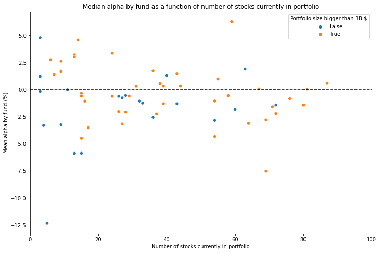

```python
plt.figure(figsize=(12,8))
sns.scatterplot(x=buys_1sem_grouped_by_investors['stocks_in_port'],y=buys_1sem_grouped_by_investors['diff']*100,hue=buys_1sem_grouped_by_investors['Portfolio size bigger than 1B $'])
plt.xlim([0,100])
plt.hlines(0,0,100,'black',linestyles='--')
plt.ylabel('Mean alpha by fund (%)')
plt.xlabel('Number of stocks currently in portfolio')
plt.title('Median alpha by fund as a function of number of stocks currently in portfolio');
#md('Bigger portfolios normally have a higher number of stocks. Also, as expected, funds with a lower number of stocks in portfolio have a higher volatility. Unfortunately, portfolio size does not seem to indicate wheter or not a fund overperforms the SPY')
```

## 4.3 Metrics analysis

After analyzing the individual buy/sell actions of each investor, the actions are grouped together into transactions (unique combination of stock and quarter). For each transaction, the number of different funds that bought/sold were counted. The net % change was also calculated, taking into account the "% change to portfolio" of each fund action.

Finally, a net investor score was also calculated. This uses information about the top performing funds in the period before 2018.

So, if fund 1 (weight 2.5) and fund 2 (weight 1) bought, while fund 3 (weight 4) sold the stock. The net investor score would be: 2.5+1-4=-0.5

A summary of some of these unique transactions is shown in the table below.

```python
def generate_df_transaction_metrics(data):
    dict_metrics={}

    for index, row in data.iterrows():
        if not row['Quarter'] in dict_metrics:
            dict_metrics[row['Quarter']]={}
        if not row['Ticker'] in dict_metrics[row['Quarter']]:
            if row['Action']=='Buy':
                # buys, sells, net buy/sells, net change, buyer list, seller list, return 1sem+45, return 1sem+45spy, return 1sem, return 1sem spy, return between end of sem and start of filings
                dict_metrics[row['Quarter']][row['Ticker']]=[1,0,1,row['% change to portfolio'],[row['Investor']],[],row['Inc_1sem+45'],row['Inc_1sem+45_spy'],row['Inc_1sem'],row['Inc_1sem_spy'],(row['start_filings_price']-row['end_price'])/row['start_filings_price'],(row['start_filings_price_spy']-row['end_price_spy'])/row['end_price_spy'],row['Company'],investor_score[row['Investor']]]
            elif row['Action']=='Sell':
                dict_metrics[row['Quarter']][row['Ticker']]=[0,1,-1,-row['% change to portfolio'],[],[row['Investor']],row['Inc_1sem+45'],row['Inc_1sem+45_spy'],row['Inc_1sem'],row['Inc_1sem_spy'],(row['start_filings_price']-row['end_price'])/row['start_filings_price'],(row['start_filings_price_spy']-row['end_price_spy'])/row['end_price_spy'],row['Company'],-investor_score[row['Investor']]]
        else:
            if row['Action']=='Buy':
                dict_metrics[row['Quarter']][row['Ticker']][0]+=1
                dict_metrics[row['Quarter']][row['Ticker']][2]+=1
                dict_metrics[row['Quarter']][row['Ticker']][3]+=row['% change to portfolio']
                dict_metrics[row['Quarter']][row['Ticker']][4]+=[row['Investor']]
                dict_metrics[row['Quarter']][row['Ticker']][-1]+=investor_score[row['Investor']]

            elif row['Action']=='Sell':
                dict_metrics[row['Quarter']][row['Ticker']][1]+=1
                dict_metrics[row['Quarter']][row['Ticker']][2]-=1
                dict_metrics[row['Quarter']][row['Ticker']][3]-=row['% change to portfolio']
                dict_metrics[row['Quarter']][row['Ticker']][5]+=[row['Investor']]
                dict_metrics[row['Quarter']][row['Ticker']][-1]-=investor_score[row['Investor']]

    df_transactions=pd.DataFrame.from_dict({'{} / {}'.format(i,j): dict_metrics[i][j]
                            for i in dict_metrics.keys()
                            for j in dict_metrics[i].keys()},
                        orient='index',columns=['Buys','Sells','Net Buy/Sells','Net % change','Buyers','Sellers','Inc_1sem+45','Inc_1sem+45_spy','Inc_1sem','Inc_1sem_spy','Inc_between_semester_end_start_filings','Inc_between_semester_end_start_filings_spy','Company','Net investor score']).reset_index()
    df_transactions['Quarter']=df_transactions['index'].apply(lambda x:x.split(' / ')[0])
    df_transactions['Ticker']=df_transactions['index'].apply(lambda x:x.split(' / ')[1])
    df_transactions=df_transactions.drop('index',axis=1)
    df_transactions['Alpha_1sem']=df_transactions['Inc_1sem']-df_transactions['Inc_1sem_spy']
    df_transactions['Alpha_1sem+45']=df_transactions['Inc_1sem+45']-df_transactions['Inc_1sem+45_spy']
    df_transactions['Alpha_between_semester_end_start_fillings']=df_transactions['Inc_between_semester_end_start_filings']-df_transactions['Inc_between_semester_end_start_filings_spy']
    df_transactions['Net % change bins']=pd.cut(df_transactions['Net % change'],np.linspace(-10,10,20))
    df_transactions['Net investor score bins']=pd.cut(df_transactions['Net investor score'],np.linspace(-10,10,20))
    df_transactions['Net Buy/Sells bins']=pd.cut(df_transactions['Net Buy/Sells'],[-100,-2.5,-1.5,-0.5,0.5,1.5,2.5,100],labels=['-3 or less','-2','-1','0','1','2','3 or more'])
    df_transactions['Alpha_1sem bins']=pd.qcut(df_transactions['Alpha_1sem'],10)
    df_transactions['Alpha_between_semester_end_start_fillings bins']=pd.qcut(df_transactions['Alpha_between_semester_end_start_fillings'],10)
    return df_transactions
df_transactions=generate_df_transaction_metrics(data_filt)
df_transactions[['Quarter','Ticker','Buys','Sells','Net Buy/Sells','Net % change','Net investor score','Buyers','Sellers','Alpha_1sem+45']].sort_values(by='Net Buy/Sells')
```

|  | Quarter | Ticker | Buys | Sells | Net Buy/Sells | Net % change | Net investor score | Buyers | Sellers | Alpha_1sem+45 |
| --- | --- | --- | --- | --- | --- | --- | --- | --- | --- | --- |
| 790 | 2020 Q3 | AMZN | 0 | 8 | -8 | -26.63 | -21.0 | [] | [Christopher Davis , ClearBridge Value Trust, ... | -0.033888 |
| 2743 | 2018 Q2 | TWX | 0 | 6 | -6 | -20.94 | -14.0 | [] | [Chris Hohn , David Abrams , David Einhorn , D... | 0.026576 |
| 1016 | 2020 Q2 | GOOGL | 0 | 6 | -6 | -17.95 | -15.0 | [] | [Bill Nygren , ClearBridge Value Trust, Greg A... | 0.088187 |
| 1994 | 2019 Q2 | MSFT | 0 | 5 | -5 | -12.14 | -14.5 | [] | [Bill & Melinda Gates Foundation Trust, Harry ... | 0.001298 |
| 4375 | 2015 Q4 | MSFT | 0 | 5 | -5 | -14.93 | -11.0 | [] | [David Katz , Glenn Greenberg , Hillman Value ... | -0.095643 |
| ... | ... | ... | ... | ... | ... | ... | ... | ... | ... | ... |
| 1952 | 2019 Q3 | CRM | 4 | 0 | 4 | 8.14 | 10.0 | [John Armitage , Stephen Mandel , Viking Globa... | [] | 0.063061 |
| 257 | 2021 Q1 | BABA | 5 | 1 | 4 | 16.05 | 9.5 | [Charlie Munger , Greg Alexander , Leon Cooper... | [David Tepper ] | -0.195272 |
| 1712 | 2019 Q4 | VIAC | 6 | 0 | 6 | 20.91 | 16.0 | [Charles Bobrinskoy , ClearBridge Value Trust,... | [] | -0.359362 |
| 1313 | 2020 Q1 | FB | 9 | 3 | 6 | 18.62 | 10.5 | [Bill Nygren , David Abrams , David Katz , Gle... | [David Rolfe , David Tepper , Viking Global In... | 0.081255 |
| 3000 | 2018 Q1 | FB | 10 | 0 | 10 | 24.93 | 25.5 | [Christopher Davis , David Rolfe , David Teppe... | [] | -0.068950 |

6040 rows × 10 columns

```python
md('There were a total of **{}** unique transactions.'.format(df_transactions.shape[0]))
```

There were a total of **6040** unique transactions.

### 4.3.1 Net Buy/Sells

Two plots were obtained using the amount of times the stock was bought more than it was sold by funds.

In the first, the stocks were grouped by the Net Buy/Sells integer value. Overall, stocks that had a high net value overperformed those with lowest net value. In fact, the top2% selected according to this metric had an alpha 6% higher than the bottom 2%.

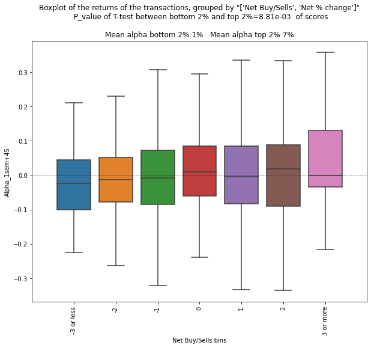

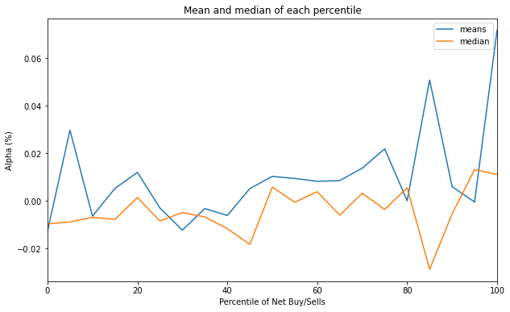

```python
groups_with_enough_data=[]
count_netbuysells=df_transactions.groupby('Net Buy/Sells').count()
for index,row in count_netbuysells.iterrows():
    if row['Buys']>20:
        groups_with_enough_data+=[index]
df_transactions_filt=df_transactions[df_transactions['Net Buy/Sells'].apply(lambda x: x in groups_with_enough_data)]
df_transactions['Alpha_1sem+45']=df_transactions['Alpha_1sem+45']*100
df_transactions['Alpha_1sem']=df_transactions['Alpha_1sem']*100
df_transactions['Alpha_between_semester_end_start_fillings']=df_transactions['Alpha_between_semester_end_start_fillings']*100
def plot_bloxplot_strategies(data_transactions,var_box,var_reg,additional_comment):
    plt.figure(figsize=(10,8))
    sns.boxplot(data=data_transactions, x=var_box,y='Alpha_1sem+45',
                    showfliers=False)
    plt.plot([-1,len(pd.unique(data_transactions[var_box]))],[0,0],'k--',linewidth=0.4)
    plt.xlim(-1,len(pd.unique(data_transactions[var_box])))
    data_transactions=data_transactions.sort_values(by=var_reg)
    number_samples=data_transactions.shape[0]
    top_2pct_alpha=data_transactions.tail(number_samples//50)['Inc_1sem+45']
    bottom_2pct_alpha=data_transactions.head(number_samples//50)['Inc_1sem+45']
    mean_top=np.mean(top_2pct_alpha)*100
    mean_bottom=np.mean(bottom_2pct_alpha)*100
    x=data_transactions[[var_reg[0]]]
    y_cap=df_transactions['Alpha_1sem+45'].quantile(.96)
    y=data_transactions['Alpha_1sem+45'].apply(lambda x_var:min(x_var,y_cap))
    model=sm.OLS(y,x).fit()
    slope=model.params[0]
    #p_value=pd.read_html(model.summary().tables[1].as_html(),header=0,index_col=0)[0]['P>|t|'][0]
    _,p_value=ttest_ind(top_2pct_alpha,bottom_2pct_alpha)
    plt.title('Boxplot of the returns of the transactions, grouped by "{}"\n P_value of T-test between bottom 2% and top 2%={:.2e}  of scores\n{}\nMean alpha bottom 2%:{:.0f}%   Mean alpha top 2%:{:.0f}%'.format(var_reg,p_value,additional_comment,mean_bottom,mean_top))
    plt.xticks(rotation=90)


    number_samples=data_transactions.shape[0]//20
    percentiles=np.arange(21)*5
    medians=[]
    means=[]
    data_transactions=data_transactions.sort_values(by=var_reg)
    for i in np.arange(21):
        means+=[data_transactions.iloc[i*number_samples:(i+1)*number_samples]['Alpha_1sem+45'].mean()]
        medians+=[data_transactions.iloc[i*number_samples:(i+1)*number_samples]['Alpha_1sem+45'].median()]
    plt.figure(figsize=(10,6))
    plt.title('Mean and median of each percentile')
    plt.plot(percentiles,means,label='means')
    plt.plot(percentiles,medians,label='median')
    plt.legend()
    plt.xlim(0,100)
    plt.xlabel('Percentile of {}'.format(var_reg[0]))
    plt.ylabel('Alpha (%)');

plot_bloxplot_strategies(df_transactions_filt,'Net Buy/Sells bins',['Net Buy/Sells','Net % change'],'')
```

### 4.3.2 Net % change

Similar to the previous case, the data was divided in bins according to the "Net % change" metric. In a similar way, funds that had a higher score performed better than funds with a lower score.

As happened in the previous case, the alphas were very noisy as they had a very high standard deviation.

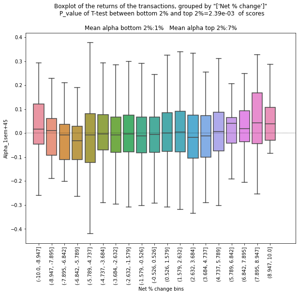

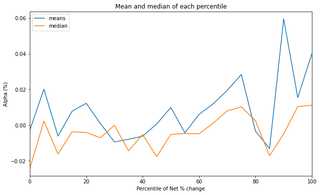

```python
plot_bloxplot_strategies(df_transactions_filt,'Net % change bins',['Net % change'],'')
```

### 4.3.3 Net investor score

In the third metric (which is based on the performance of the funds until 2018, and is only tested in the period after 2018 to not introduce any bias to the data), the observed behavior was not as well divided between the bottom half and upper half as was in the two previous cases. The top percentiles, however, seemed to perform much better than the others.

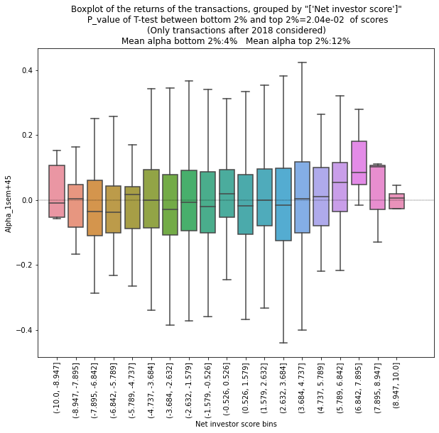

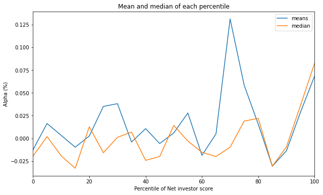

```python
df_transactions_above_2018=df_transactions_filt[df_transactions_filt['Quarter'].apply(lambda x:int(x.split(' ')[0]))>=2018]

plot_bloxplot_strategies(df_transactions_above_2018,'Net investor score bins',['Net investor score'],'(Only transactions after 2018 considered)')
```

## 4.4 Effect of realized returns on the returns after the filings date.

Another effect to explore was whether the return after the filings date would be lower if the stock price already increased in:

- the past semester
- between the end of the semester and the filings date.

The plot below shows the alpha value in both periods for funds with highest and lowest "net buy/sells". As all correlations were lower than 0.3, there does not seem to be any clear correlation between oscillations previous to the filings date and the alpha after the date.

By this logic, a stock that was bought by a lot of funds and increased by 10% before the filings date and a stock that was bought by a lot of funds and decreased by 10% before the filings date should have a similar performance on average.

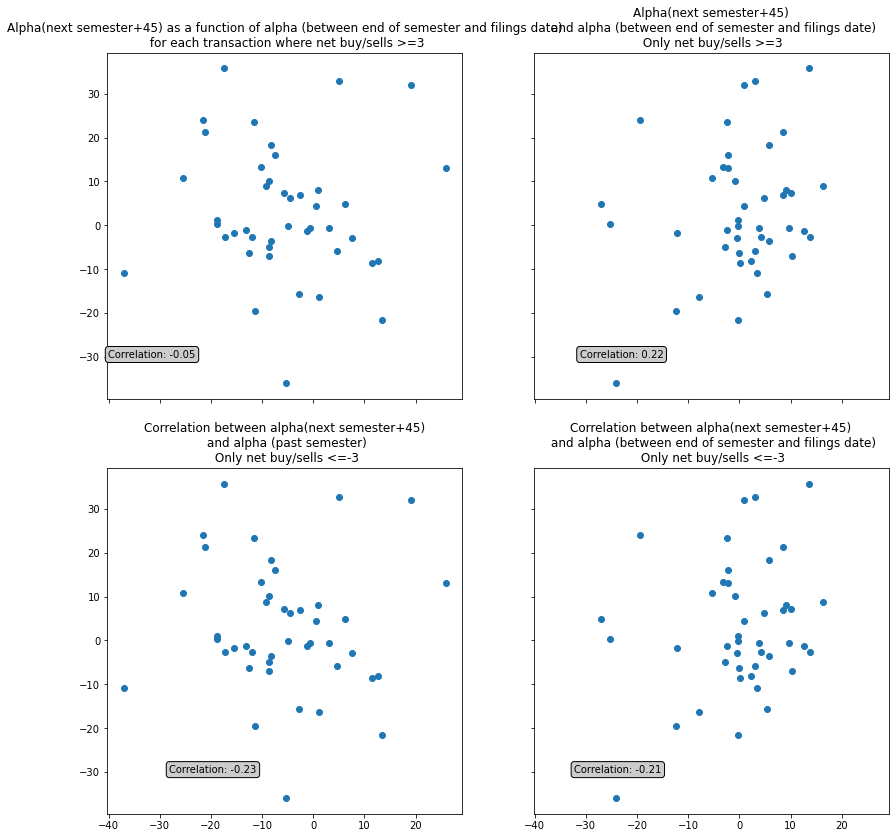

```python
#######Understanding the effects that a rise or fall in price before the filings date may have in the performance after the filings date
bbox_args = dict(boxstyle="round", fc="0.8")

filtered_top=df_transactions[df_transactions['Net Buy/Sells']>=3]
filtered_bottom=df_transactions[df_transactions['Net Buy/Sells']<=-3]
fig,axs=plt.subplots(2,2,figsize=(14,14),sharex=True,sharey=True)

axs[0][0].scatter(filtered_top['Alpha_1sem'],filtered_top['Alpha_1sem+45'])
axs[0][0].set_title('Alpha(next semester+45) as a function of alpha (past semester)\n for each transaction where net buy/sells >=3')

axs[0][1].scatter(filtered_top['Alpha_between_semester_end_start_fillings'],filtered_top['Alpha_1sem+45'])
axs[0][0].set_title('Alpha(next semester+45) as a function of alpha (between end of semester and filings date)\n for each transaction where net buy/sells >=3')

axs[0][1].set_title('Alpha(next semester+45)\n and alpha (between end of semester and filings date)\n Only net buy/sells >=3')

axs[1][0].scatter(filtered_top['Alpha_1sem'],filtered_top['Alpha_1sem+45'])
axs[1][0].set_title('Correlation between alpha(next semester+45)\n and alpha (past semester)\n Only net buy/sells <=-3')

axs[1][1].scatter(filtered_top['Alpha_between_semester_end_start_fillings'],filtered_top['Alpha_1sem+45'])
axs[1][1].set_title('Correlation between alpha(next semester+45)\n and alpha (between end of semester and filings date)\n Only net buy/sells <=-3')

corr_plot=pearsonr(filtered_top['Alpha_1sem'],filtered_top['Alpha_1sem+45'])[0]
axs[0][0].annotate('Correlation: {:.2f}'.format(corr_plot),xy=(min(filtered_top['Alpha_1sem'])*0.85,0.2), xycoords=("data", 'axes fraction'),
                    xytext=(0, -20), textcoords='offset points',
                    ha="center", va="top",
                    bbox=bbox_args)

corr_plot=pearsonr(filtered_top['Alpha_between_semester_end_start_fillings'],filtered_top['Alpha_1sem+45'])[0]
axs[0][1].annotate('Correlation: {:.2f}'.format(corr_plot),xy=(min(filtered_top['Alpha_between_semester_end_start_fillings'])*0.85,0.2), xycoords=("data", 'axes fraction'),
                    xytext=(0, -20), textcoords='offset points',
                    ha="center", va="top",
                    bbox=bbox_args)
corr_plot=pearsonr(filtered_bottom['Alpha_1sem'],filtered_bottom['Alpha_1sem+45'])[0]
axs[1][0].annotate('Correlation: {:.2f}'.format(corr_plot),xy=(min(filtered_bottom['Alpha_1sem'])*0.85,0.2), xycoords=("data", 'axes fraction'),
                    xytext=(0, -20), textcoords='offset points',
                    ha="center", va="top",
                    bbox=bbox_args)

corr_plot=pearsonr(filtered_bottom['Alpha_between_semester_end_start_fillings'],filtered_bottom['Alpha_1sem+45'])[0]
axs[1][1].annotate('Correlation: {:.2f}'.format(corr_plot),xy=(min(filtered_bottom['Alpha_between_semester_end_start_fillings'])*0.85,0.2), xycoords=("data", 'axes fraction'),
                    xytext=(0, -20), textcoords='offset points',
                    ha="center", va="top",
                    bbox=bbox_args)
```

# 5. Simulating strategies

Each of the three proposed metrics was simulated using the following methodology:

## 5.1 Method 1: Net Buy/Sells

By simulating the method for the entire period (2013-2021), the method managed to perform better than the S&P. On the other hand, the reverse method also managed to underperform the S&P.

The scatterplot shows that the method, most of times, performed above the S&P, but there were some quarters it did underperform. The method was also much more noisier than the S&P: It managed to have both the highest and lowest return.

```python
def simulate_compound_growth(df_transactions,period_range,metric,print_p_values,number_of_selections,
                             plot_scatter_graph_period,plot_return_over_time):
    dict_methods={'Net Buy/Sells':1,'Net % change':2,'Net investor score':3}
    method=dict_methods[metric[0]]
    quarters=[]
    year_dates=[]
    bought_by_quarter={}

    for y in np.arange(period_range[0],period_range[1]):
        for q in np.arange(1,5):
            quarters+=['{} Q{}'.format(y,q)]
            if q==4:
                year_dates+=[datetime.datetime(y+1,3,1)]
            else:
                year_dates+=[datetime.datetime(y,1+(q)*3,1)]
            if y==2021 and q==1:break

    inc_spy=[]
    inc_method_p=[]
    inc_method_n=[]
    inc_method_rand=[]
    bought_by_quarter={}
    sold_by_quarter={}
    vector_gains_p=[]
    vector_gains_n=[]
    for quarter in quarters:
        df=df_transactions[df_transactions['Quarter']==quarter]
        inc_spy+=[df.iloc[0]['Inc_1sem+45_spy']]

        bought_by_quarter[quarter]=list(df.sort_values(by=metric,ascending=False).iloc[0:number_of_selections].apply(lambda x:x['Ticker']+' - '+x['Company'][:15]+  '(Net:{:.1f}) '.format(x[metric[0]])+'Return:{:.1f}% '.format(x['Inc_1sem+45']*100),axis=1))
        sold_by_quarter[quarter]=list(df.sort_values(by=metric,ascending=True).iloc[0:number_of_selections].apply(lambda x:x['Ticker']+' - '+x['Company'][:15]+  '(Net:{:.1f})'.format(x[metric[0]])+' Return:{:.1f}% '.format(x['Inc_1sem+45']*100),axis=1))
        inc_method_p+=[df.sort_values(by=metric,ascending=False).iloc[0:number_of_selections]['Inc_1sem+45'].mean()]
        inc_method_n+=[df.sort_values(by=metric,ascending=True).iloc[0:number_of_selections]['Inc_1sem+45'].mean()]
        inc_method_rand+=[df.sample(frac=1).reset_index(drop=True).iloc[0:number_of_selections]['Inc_1sem+45'].mean()]
        bought_by_quarter[quarter]+=['SPY - Return: {:.1f}%'.format(df.iloc[0]['Inc_1sem+45_spy']*100)]
        bought_by_quarter[quarter]+=['Mean - Return: {:.1f}%'.format(df.sort_values(by=metric,ascending=False).iloc[0:number_of_selections]['Inc_1sem+45'].mean()*100)]
        sold_by_quarter[quarter]+=['SPY - Return: {:.1f}%'.format(df.iloc[0]['Inc_1sem+45_spy']*100)]
        sold_by_quarter[quarter]+=['Mean - Return: {:.1f}%'.format(df.sort_values(by=metric,ascending=True).iloc[0:number_of_selections]['Inc_1sem+45'].mean()*100)]
        vector_gains_p+=[[quarter,df.iloc[0]['Inc_1sem+45_spy']*100,df.sort_values(by=metric,ascending=False).iloc[0:number_of_selections]['Inc_1sem+45'].mean()*100]]
        vector_gains_n+=[[quarter,df.iloc[0]['Inc_1sem+45_spy']*100,df.sort_values(by=metric,ascending=True).iloc[0:number_of_selections]['Inc_1sem+45'].mean()*100]]

    bought_by_quarter_method=pd.DataFrame.from_dict(bought_by_quarter)
    sold_by_quarter_method=pd.DataFrame.from_dict(sold_by_quarter)

    series_spy=[1]
    series_method_p=[1]
    series_method_n=[1]
    series_random=[1]
    for i in np.arange(len(inc_spy)):
        series_spy+=[series_spy[-1]*(1+inc_spy[i])]
        series_method_p+=[series_method_p[-1]*(1+inc_method_p[i])]
        series_method_n+=[series_method_n[-1]*(1+inc_method_n[i])]
        series_random+=[series_random[-1]*(1+inc_method_rand[i])]
    comp_growth_spy=(series_spy[-1]**(1/len(series_spy))-1)*100
    comp_growth_p=(series_method_p[-1]**(1/len(series_method_p))-1)*100
    comp_growth_n=(series_method_n[-1]**(1/len(series_method_n))-1)*100
    comp_growth_rand=(series_random[-1]**(1/len(series_random))-1)*100

    if plot_return_over_time:
        plt.figure(figsize=(10,8))
        plt.plot(year_dates,series_spy[1:],label='SPY -> compound growth:{:.2f}%'.format(comp_growth_spy))
        plt.plot(year_dates,series_method_p[1:],label='Method (Top {}) -> compound growth:{:.2f}%'.format(number_of_selections,comp_growth_p))
        plt.plot(year_dates,series_method_n[1:],label='Method (Bottom {}) -> compound growth:{:.2f}%'.format(number_of_selections,comp_growth_n))
        plt.legend()
        plt.title('Method {} - Buying based on {}'.format(method,metric[0]))
        plt.xlabel('Date')
        plt.ylabel('Increase since {} Q1'.format(period_range[0]))


    p_value_p=ttest_rel(inc_method_p,inc_spy)[1]
    p_value_n=ttest_rel(inc_method_n,inc_spy)[1]
    p_value_p_n=ttest_rel(inc_method_n,inc_method_p)[1]


    if print_p_values:
        print('Performing a paired t-test (two samples are related) for method {}. P-values:\n Method vs SPY: {:.2e}\n Inverse Method vs SPY: {:.2e}\n Inverse Method vs Method: {:.2e}'.format(method,p_value_p,p_value_n,p_value_p_n))
    if plot_scatter_graph_period:
        df_gains=pd.DataFrame(vector_gains_p,columns=['Quarter','Spy','Method'])

        fig,ax=plt.subplots(1,1,figsize=(10,10))
        df1=df
        ax.scatter(y=df_gains['Quarter'], x=df_gains['Method'], s=75, color='red', alpha=1,zorder=2,label='Return method',marker='o')
        ax.scatter(y=df_gains['Quarter'], x=df_gains['Spy'], s=75, color='blue', alpha=1,zorder=2,label='Return SPY',marker='^')
        ax.legend(loc=2)
        for i, p1, p2 in zip(df_gains['Quarter'], df_gains['Method'], df_gains['Spy']):
            if p1>p2:color='green'
            else:color='red'
            newline([p1, i], [p2, i],ax,color)
        plt.xlabel('Return in Quarter (%)')
        plt.ylabel('Quarter')
        plt.title('Return of method when compared to SPY return QoQ')

        df_gains=pd.DataFrame(vector_gains_n,columns=['Quarter','Spy','Method'])

        fig,ax=plt.subplots(1,1,figsize=(10,10))
        df1=df
        ax.scatter(y=df_gains['Quarter'], x=df_gains['Method'], s=75, color='red', alpha=1,zorder=2,label='Return method',marker='o')
        ax.scatter(y=df_gains['Quarter'], x=df_gains['Spy'], s=75, color='blue', alpha=1,zorder=2,label='Return SPY',marker='^')
        ax.legend(loc=2)
        for i, p1, p2 in zip(df_gains['Quarter'], df_gains['Method'], df_gains['Spy']):
            if p1>p2:color='green'
            else:color='red'
            newline([p1, i], [p2, i],ax,color)
        plt.xlabel('Return in Quarter (%)')
        plt.ylabel('Quarter')
        plt.title('Return of inverse method {} when compared to SPY return QoQ'.format(method))
    return comp_growth_spy,comp_growth_p,comp_growth_n,comp_growth_rand,bought_by_quarter_method,sold_by_quarter_method
```

```
Performing a paired t-test (two samples are related) for method 1. P-values:
 Method vs SPY: 1.42e-01
 Inverse Method vs SPY: 8.55e-02
 Inverse Method vs Method: 1.14e-02
```

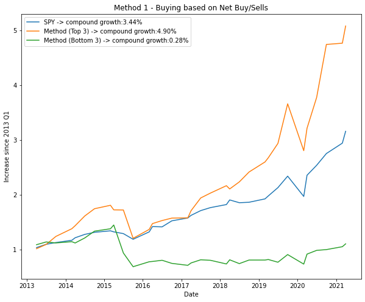

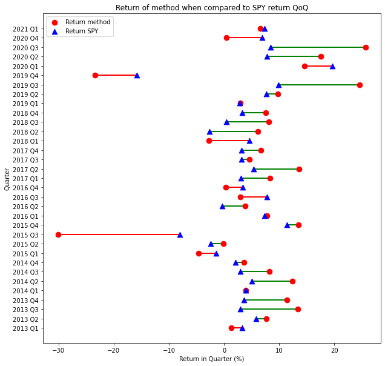

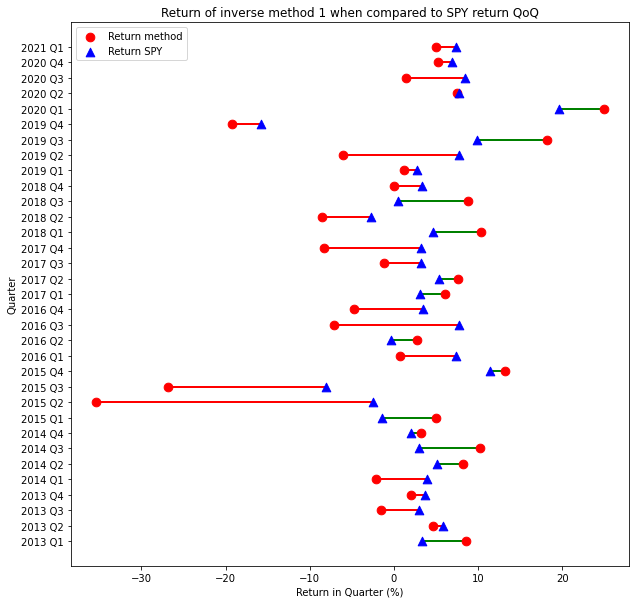

```python
_=simulate_compound_growth(df_transactions,[2013,2022],['Net Buy/Sells','Net % change'],1,number_of_selections,1,1)
```

In a similar way, the strategy was simulated for the period of 2018-2021, obtaining the returns below.

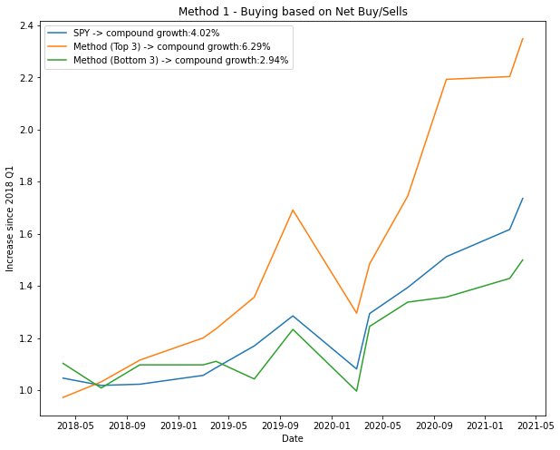

```python
_=simulate_compound_growth(df_transactions,[2018,2022],['Net Buy/Sells','Net % change'],0,number_of_selections,0,1)
```

## 5.2 Method 2: Net % change

The second method, based not only in how many funds are buying the stock, but also the amount in which they are buying, also managed to beat the S&P and obtain a higher compound growth when compared to method 1.

```
Performing a paired t-test (two samples are related) for method 2. P-values:
 Method vs SPY: 8.68e-02
 Inverse Method vs SPY: 1.95e-01
 Inverse Method vs Method: 1.50e-02
```

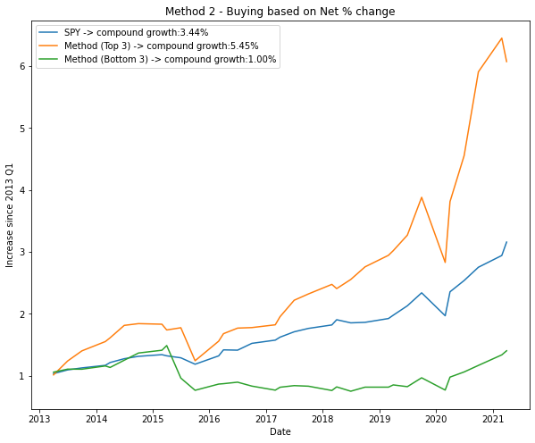

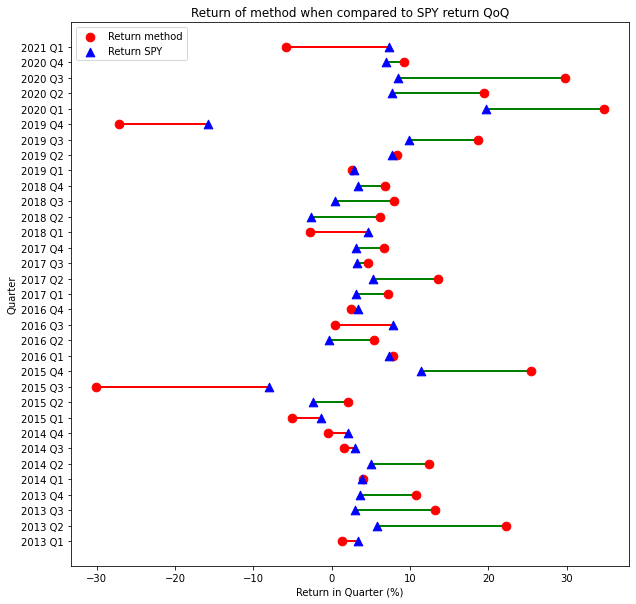

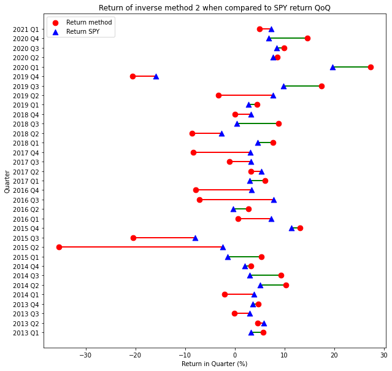

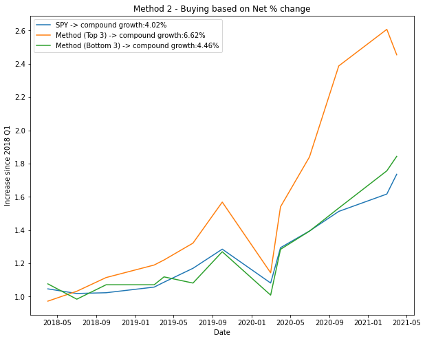

```python
_=simulate_compound_growth(df_transactions,[2013,2022],['Net % change'],1,number_of_selections,1,1)
_=simulate_compound_growth(df_transactions,[2018,2022],['Net % change'],0,number_of_selections,0,1)
```

## 5.3 Method 3: Net investor score

The third method was only simulated in the period 2018-2021 (as the investor scores were based on the performance in the period 2013-2017).

The return of the method was very similar to the other 2 methods. Coupling this with the fact that the analysis section did not indicate any relation between past and future performance, I decide to not analyze method 3 furthermore. Instead the focus will only be in the first 2 methods.

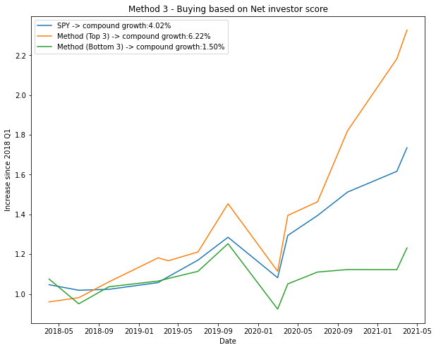

```python
_=simulate_compound_growth(df_transactions,[2018,2022],['Net investor score'],0,number_of_selections,0,1)
```

# 6. Sensitivity analysis

## 6.1 Method 1: Net Buy/Sells

To understand how the performance changes with parameters, a sensibility analysis will be performed. Using each combination of variables, the compound growth will be calculated and compared with the growth of the SPY in the same period. The sensibility analysis will also use a random selection of stocks to compare the method results.

The analysis will be separated in two periods: 2013-2017 and 2018-2021. This is done so that some considerations/analysis can be made based upon the 2013-2017 period analysis. These conclusions are then applied to the 2018-2021 to see if they hold.

The following combinations will be considered:

1. Minimum % of portfolio change (0.5%, 1%, 1.5%, 2%)
2. Maximum stocks in fund portfolio (50,100,1000)
3. Top stocks to select (2,3,4,5,6,8)

The results for the first method are shown below:

```python
##########################################################3
##############SENSIBILITY ANALYSIS#######################
###################################################

def plot_sensitibity_compound_growth(minimum_percent_list,max_stocks,top_to_select_list,perc_increase_cap_list,metric,starting_date,ending_date):

    data= read_data_excel()

    data_sensitivity=[]

    if metric[0]=='Net Buy/Sells':
        product_comb=itertools.product(minimum_percent_list,max_stocks,top_to_select_list)
    elif metric[0]=='Net % change':
        product_comb=itertools.product(perc_increase_cap_list,max_stocks,top_to_select_list)



    for iterative1,iterative2,iterative3 in product_comb:
        if metric[0]=='Net Buy/Sells':
            filter_percent_port=iterative1
            perc_increase_cap=perc_increase_cap_list[0]
        elif metric[0]=='Net % change':
            perc_increase_cap=iterative1
            filter_percent_port=minimum_percent_list[0]
        max_number_of_stocks_in_port=iterative2
        top_to_select=iterative3

        #t0=time.time()
        data_filt=data_filter_and_process(data,filter_percent_port,max_number_of_stocks_in_port,perc_increase_cap)
        data_filt[(data_filt['year']>=starting_date)&(data_filt['year']<ending_date)]
        #print(0,(time.time()-t0))
        #t0=time.time()

        df_transactions=generate_df_transaction_metrics(data_filt)
        #print(1,(time.time()-t0))
        #t0=time.time()
        comp_growth_spy,comp_growth_p,comp_growth_n,comp_growth_rand,_,_=simulate_compound_growth(df_transactions,[starting_date,ending_date],metric,0,top_to_select,0,0)
        #print(2,(time.time()-t0))
        #t0=time.time()

        data_sensitivity+=[[perc_increase_cap,filter_percent_port,max_number_of_stocks_in_port,top_to_select,comp_growth_p,comp_growth_n,comp_growth_rand]]

    df_sensibility=pd.DataFrame(data_sensitivity,columns=['perc_inc_cap','filter_percent','filter_n_stocks','numb_selections','method','method_n','method_random'])

    for filter_n_stocks_sel in max_stocks:
        fig=plt.figure(figsize=(16,10))
        outer_grid = gridspec.GridSpec(1,3, wspace=0.1, hspace=0)
        for i in np.arange(3):
            if i==0:
                method='method'
            elif i==1:
                method='method_n'
            else:
                method='method_random'
            df_sensibility_filt=df_sensibility[df_sensibility['filter_n_stocks']==filter_n_stocks_sel]
            mean_total=np.mean(df_sensibility_filt[method])
            std_dev_tot=np.std(df_sensibility_filt[method])

            mean_by_percent=df_sensibility_filt.groupby(['filter_percent']).mean()[[method]]
            std_by_percent=df_sensibility_filt.groupby(['filter_percent']).std()[[method]]

            mean_by_n_sel=df_sensibility_filt.groupby(['numb_selections']).mean()[[method]]
            std_by_n_sel=df_sensibility_filt.groupby(['numb_selections']).std()[[method]]
            if metric[0]=='Net Buy/Sells':
                df_pivot=df_sensibility_filt.pivot(index='numb_selections',columns='filter_percent',values=method)
                mean_by_percent=df_sensibility_filt.groupby(['filter_percent']).mean()[[method]]
                std_by_percent=df_sensibility_filt.groupby(['filter_percent']).std()[[method]]
            elif metric[0]=='Net % change':
                df_pivot=df_sensibility_filt.pivot(index='numb_selections',columns='perc_inc_cap',values=method)
                mean_by_percent=df_sensibility_filt.groupby(['perc_inc_cap']).mean()[[method]]
                std_by_percent=df_sensibility_filt.groupby(['perc_inc_cap']).std()[[method]]
            gspec= gridspec.GridSpecFromSubplotSpec(40,40, subplot_spec=outer_grid[i])
            ax = plt.Subplot(fig, outer_grid[i])
            fig.suptitle('Choosing only funds with less than {} stocks in portfolio         Obs: Compound growth SPY (QoQ):{:.1f}%         Period:{}-{}'.format(filter_n_stocks_sel,comp_growth_spy,starting_date,ending_date-1))
            left_top_ax=plt.subplot(gspec[:27,:27])
            left_middle_ax=plt.subplot(gspec[28:33,:27])
            left_bottom_ax=plt.subplot(gspec[34:39,:27])

            middle_top_ax=plt.subplot(gspec[:27,28:33])
            right_top_ax=plt.subplot(gspec[:27,34:39])

            bottom_right_ax=plt.subplot(gspec[30:39,30:39])

            sns.heatmap(df_pivot,annot=True,vmin=comp_growth_spy-2,vmax=comp_growth_spy+2,fmt='.1f',cmap=cmap,ax=left_top_ax,linecolor='black',cbar=False,linewidth=1)


            left_top_ax.set_ylabel('Number of top selections chosen using method')
            if i==0:
                left_top_ax.set_title('Compound growth (QoQ) model\n')
            elif i==1:
                left_top_ax.set_title('Compound growth (QoQ) inverse model\n')
            else:
                left_top_ax.set_title('Compound growth (QoQ) random selection\n')

            sns.heatmap(mean_by_percent.T,annot=True,vmin=comp_growth_spy-2,vmax=comp_growth_spy+2,fmt='.1f',cmap=cmap,ax=left_middle_ax,linecolor='black',cbar=False,linewidth=1)
            left_middle_ax.set_ylabel('Mean')

            sns.heatmap(std_by_percent.T,annot=True,fmt='.1f',cmap='Oranges',ax=left_bottom_ax,linecolor='black',cbar=False,vmin=0,vmax=1,linewidth=1)
            left_bottom_ax.set_ylabel('Std. Dev')

            sns.heatmap(mean_by_n_sel,annot=True,vmin=comp_growth_spy-2,vmax=comp_growth_spy+2,fmt='.1f',cmap=cmap,ax=middle_top_ax,linecolor='black',cbar=False,linewidth=1)
            middle_top_ax.xaxis.set_label_position('top')
            middle_top_ax.set_xlabel('Mean')

            sns.heatmap(std_by_n_sel,annot=True,fmt='.1f',cmap='Oranges',ax=right_top_ax,linecolor='black',cbar=False,vmin=0,vmax=1,linewidth=1)
            right_top_ax.xaxis.set_label_position('top')
            right_top_ax.set_xlabel('Std. Dev')

            sns.heatmap(pd.DataFrame([mean_total,std_dev_tot],index=['Mean','Std.Dev']),annot=True,fmt='.1f',ax=bottom_right_ax,linecolor='black',cbar=False,vmin=-10**8,vmax=10**8,cmap='bwr',linewidth=1)

            bottom_right_ax.set_title('Overall')

            for ax in [left_top_ax,left_middle_ax,bottom_right_ax]:
                ax.tick_params(axis='x',which='both',labelbottom=False,bottom=False)
                ax.set_xlabel('',color='white')
            for ax in [left_bottom_ax,left_middle_ax]:
                ax.tick_params(axis='y',which='both',labelleft=False)
            for ax in [middle_top_ax,right_top_ax]:
                ax.tick_params(axis='y',which='both',labelleft=False,left=False)
                ax.set_ylabel('',color='white')
            for ax in [middle_top_ax,right_top_ax,bottom_right_ax]:
                ax.tick_params(axis='x',which='both',labelbottom=False,top=True,bottom=False)

            if metric[0]=='Net Buy/Sells':
                left_top_ax.set_xlabel('Minimum % change to portfolio of transaction')
                left_bottom_ax.set_xlabel('Minimum % change to portfolio of transaction')

            elif metric[0]=='Net % change':
                left_top_ax.set_xlabel('Cap of % change to portfolio of transaction')
                left_bottom_ax.set_xlabel('Cap of % change to portfolio of transaction')

            for ax in [left_top_ax,left_middle_ax,left_bottom_ax,middle_top_ax,right_top_ax,bottom_right_ax]:
                for t in ax.texts: t.set_text(t.get_text() + "%")
```

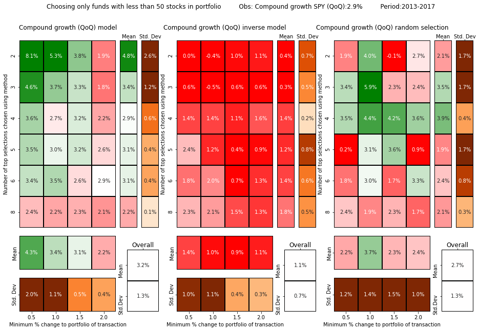

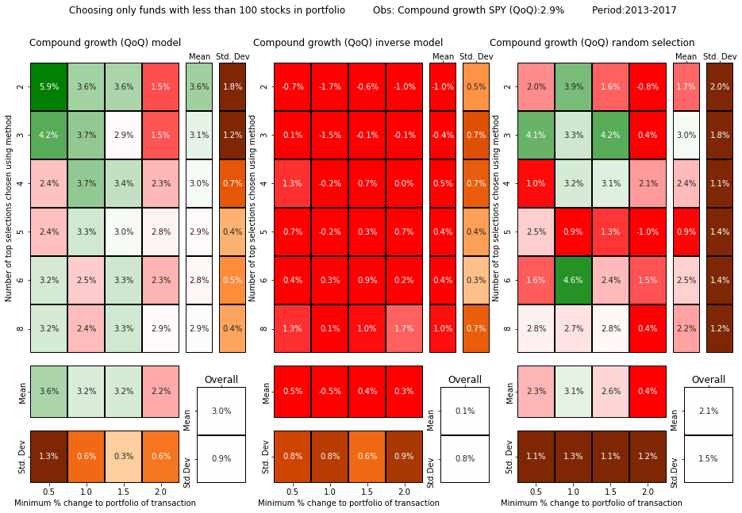

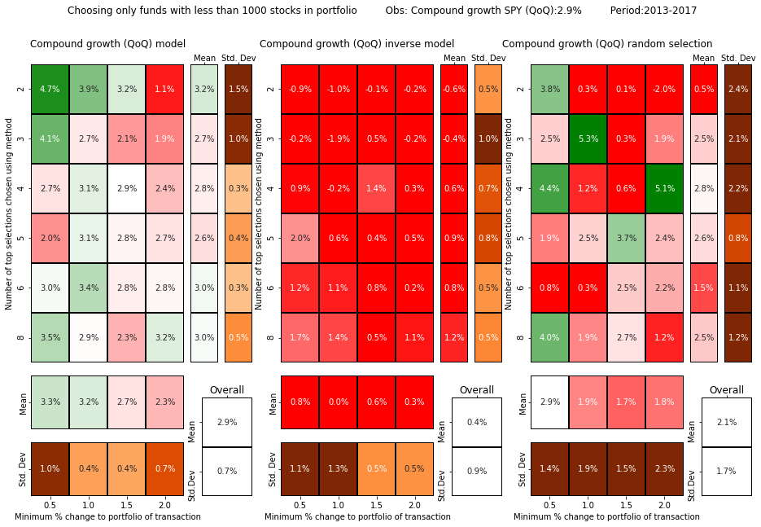

```python
minimum_percent_list=[.5,1,1.5,2]
max_stocks=[50,100,1000]
top_to_select=[2,3,4,5,6,8]
perc_increase_cap=[5]
starting_date=2013
ending_date=2018
metric=['Net Buy/Sells','Net % change']
plot_sensitibity_compound_growth(minimum_percent_list,max_stocks,top_to_select,perc_increase_cap,metric,starting_date,ending_date)
```

Now, doing the same sensibility analysis, this time for the period 2018-2021:

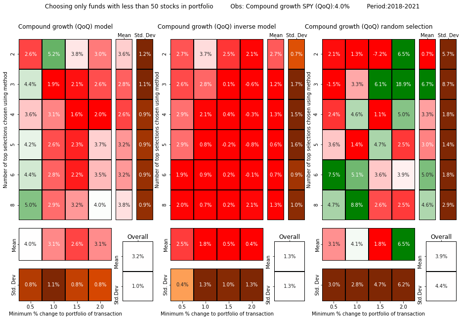

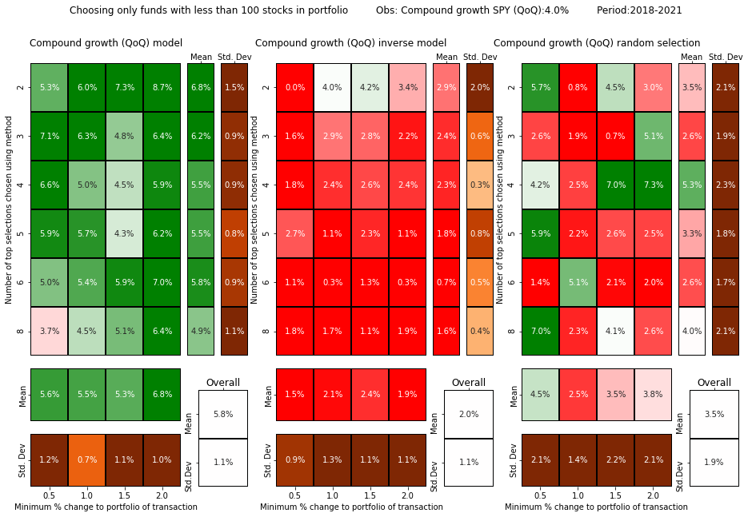

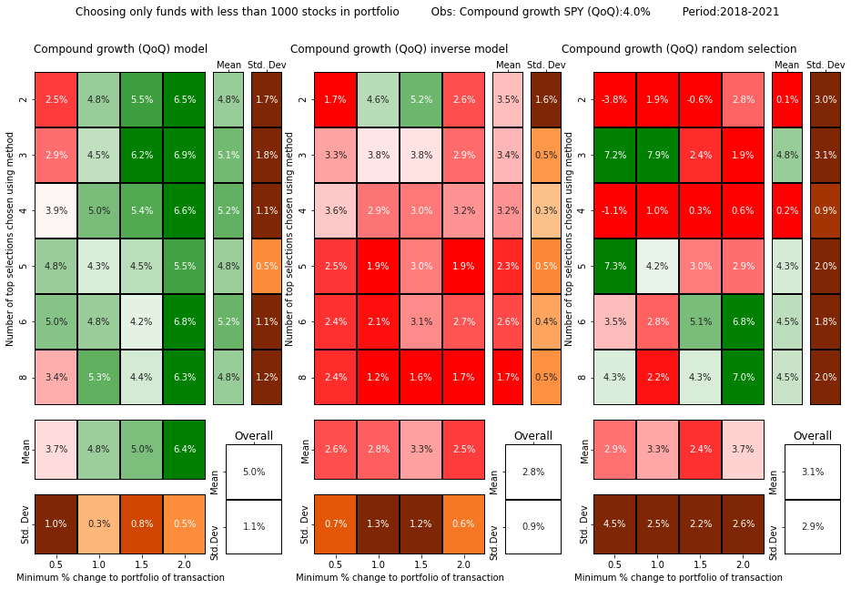

```python
starting_date=2018
ending_date=2022
plot_sensitibity_compound_growth(minimum_percent_list,max_stocks,top_to_select,perc_increase_cap,metric,starting_date,ending_date)
```

From the above sensibility table, as well as comparing to the first analysis:

1. The selection of a higher number of stocks continued to have a lower standard deviation.
2. This time the range 1, 1.5 and 2% of minimum change performed the best, thus proving the method can be very sensitive and the fact it performed well in the past is not indicative of performing well in the future.
3. Again, filtering funds with more than 100 stocks was the best out of the 3 tested values (50,100,1000)
4. The inverse method continued to underperform the method.
5. Selecting the top 2-4 stocks, using funds with 100 or less stocks and the range 0.5-1.5%, as proposed in the previous analysis, would lead to an average compound growth of 5.87%, overperforming the SPY (which had a value of 4%)

## 6.2 Method 2: Net % change

Similary to method 1, the most important parameters will be iterated and tested.

The following combinations will be considered:

1. Maximum % of portfolio change cap (2, 3, 5, 10%)
2. Maximum stocks in fund portfolio (50,100,1000)
3. Top stocks to select (2,3,4,5,6,8)
4. Minimum % of portfolio change: As this only affects the second method very little, it will not be iterated. A constant value equal to 0.2% is considered.

The results for the second method are shown below:

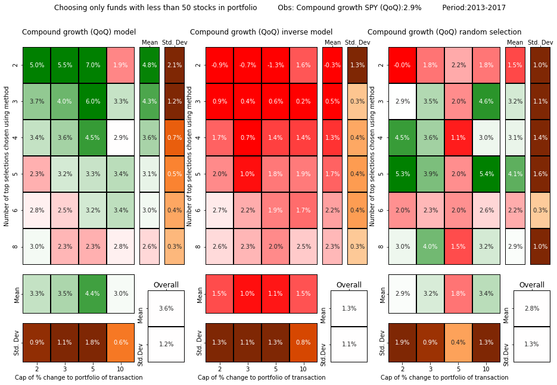

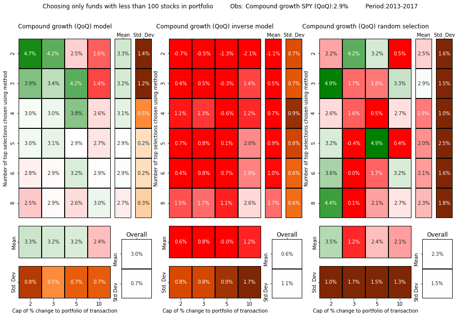

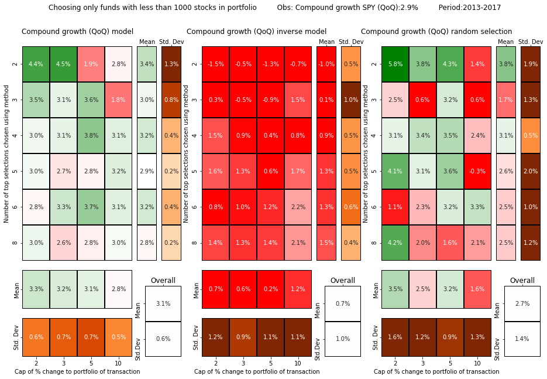

```python
minimum_percent_list=[.2]
max_stocks=[50,100,1000]
top_to_select=[2,3,4,5,6,8]
perc_increase_cap=[2,3,5,10]
starting_date=2013
ending_date=2018
metric=['Net % change']
plot_sensitibity_compound_growth(minimum_percent_list,max_stocks,top_to_select,perc_increase_cap,metric,starting_date,ending_date)
```

From the above tables, the main conclusions:

1. The method was able to identify underperforming stocks much better than overperforming stocks. All combinations of parameters in the inverse method underperformed the S&P.
2. The top 2-4 stocks selection yielded the best results.
3. The cap of 10% performed much worse than the values of 2, 3 and 5%. Out of those, the value of 5% seemed to perform a bit better than the others.
4. There was no clear advantage in the funds to select (based on maximum stocks on portfolio). The difference between the model and inverse model was 2.4% for 100 and 1000 and 2.3% for 50.